# MS2_model

## Random Forest

```r
# Set seeds and parameters for cross validation for parameter tuning with caret::train()
set.seed(432)
mySeeds <- sapply(simplify = FALSE, 1:31, function(u) sample(10^4, 5))

fitControl <- trainControl(method = "repeatedcv", number = 10,
                           repeats = 3, seeds = mySeeds,
                           returnResamp = "all",
                           savePredictions = "final") ## 3 times 10-fold CV
rfFit1 <- train(ma_range ~ ., data = imp, method = "rf",
                trControl = fitControl, verbose = FALSE,
                na.action = na.pass,
                tuneGrid=data.frame(mtry=c(2,3,4,5,6)),
                importance=TRUE)
rfFit1
```

```
## Random Forest
##
## 354 samples
##   6 predictors
##
## No pre-processing
## Resampling: Cross-Validated (10 fold, repeated 3 times)
## Summary of sample sizes: 318, 320, 318, 319, 318, 319, ...
## Resampling results across tuning parameters:
##
##   mtry  RMSE      Rsquared
##   2     5.263615  0.2341438
##   3     5.361011  0.2316503
##   4     5.434592  0.2286159
##   5     5.492875  0.2254948
##   6     5.548529  0.2175984
##
## RMSE was used to select the optimal model using  the smallest value.
## The final value used for the model was mtry = 2.
```

```r
rfFit1$finalModel
```

```
##
## Call:
##  randomForest(x = x, y = y, mtry = param$mtry, importance = TRUE,      verbose = FALSE)
##                Type of random forest: regression
##                      Number of trees: 500
## No. of variables tried at each split: 2
##
##           Mean of squared residuals: 33.95086
##                     % Var explained: 10.36
```

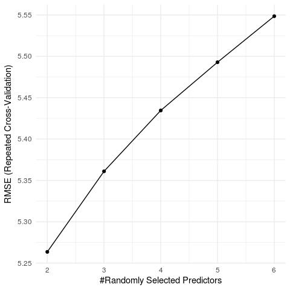

```r
ggplot(rfFit1)
```

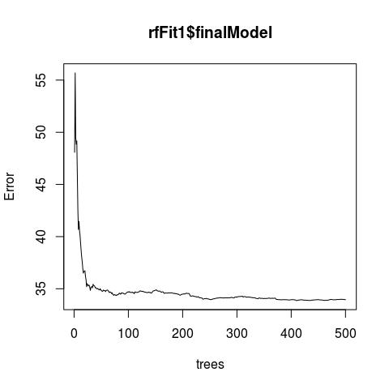

```r
plot(rfFit1$finalModel)
```

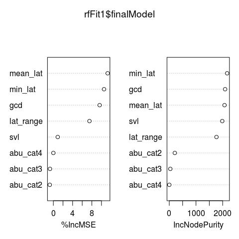

```r
varImpPlot(rfFit1$finalModel)
```

```r
### PREDICTION ####
if(class(extant$abu_cat)=="integer"){extant$abu_cat <- as.factor(extant$abu_cat)}
predict.rf <- predict(rfFit1, newdata = extant)
res$predict.rf <- predict.rf

res2 <- melt(res[,c("Red.List.status", "predict.gam", "predict.rf")])
```

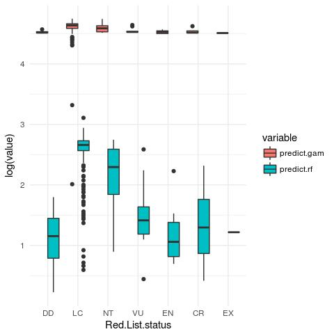

```r
theme=theme_set(theme_minimal())

ggplot(res2, aes(x=Red.List.status, y=log(value)))+
 geom_boxplot(aes(fill=variable))
```

```r
#   geom_boxplot(outlier.colour=NULL, aes(fill=variable, colour=variable))+
#  scale_y_continuous("predicted duration (log ma)")+
#  stat_summary(geom = "crossbar",
#               width=0.65, fatten=1,
#               color="black",
#               fun.data = function(x){return(c(y=median(x), ymin=median(x), ymax=median(x)))})

kruskal.test(res$predict.rf, res$Red.List.status)
```

```
##
##  Kruskal-Wallis rank sum test
##
## data:  res$predict.rf and res$Red.List.status
## Kruskal-Wallis chi-squared = 65.361, df = 6, p-value = 3.64e-12
```

```r
pairwise.wilcox.test(res$predict.rf, res$Red.List.status, p.adjust.method = "fdr")
```

```
##
##  Pairwise comparisons using Wilcoxon rank sum test
##
## data:  res$predict.rf and res$Red.List.status
##
##    DD     LC      NT     VU     EN     CR
## LC 0.0086 -       -      -      -      -
## NT 0.1510 0.0533  -      -      -      -
## VU 0.6000 2.2e-05 0.2111 -      -      -
## EN 1.0000 8.1e-05 0.0533 0.3933 -      -
## CR 0.9000 0.0115  0.3933 0.9303 0.9000 -
## EX 1.0000 0.2358  0.9000 0.9000 1.0000 1.0000
##
## P value adjustment method: fdr
```

Imputing the data does neither change prediction results or the importance of the single variables too much, but it does increase the variance explained and R squared

## Generalized boosted model

Generalized boosted models are regular regression models that are being boosted, means that they are being repeated according to the error parameters of the previous model, again and again. The cross validation can be performed by classic division of data into training and evaluation set. These models do not care about missing data, that`s a plus. They make minimal assumptions about the parameters that are being entered, however collinearity can be a problem, GBMs proof to be relatively tolerant to multicolinearity for prediction (Finnegan 2015 [see ref. 73])

```r
# parameter tuning using caret
gbmControl <- trainControl(method = "repeatedcv", number = 10,
                           repeats = 3, savePredictions = "final")

gbmGrid <-  expand.grid(interaction.depth = c(1, 2, 3),
                        n.trees = (1:10)*50,
                        shrinkage = c(0.1, 0.01, 0.001),
                        n.minobsinnode = c(5, 10, 15))
set.seed(825)
gbmFit1 <- train(ma_range ~ ., data = imp, method = "gbm",
                 trControl = gbmControl, verbose=FALSE,
                 tuneGrid=gbmGrid)
gbmFit1
```

```
## Stochastic Gradient Boosting
##
## 354 samples
##   6 predictors
##
## No pre-processing
## Resampling: Cross-Validated (10 fold, repeated 3 times)
## Summary of sample sizes: 319, 318, 318, 319, 319, 318, ...
## Resampling results across tuning parameters:
##
##   shrinkage  interaction.depth  n.minobsinnode  n.trees  RMSE
##   0.001      1                   5               50      5.605163
##   0.001      1                   5              100      5.559465
##   0.001      1                   5              150      5.517857
##   0.001      1                   5              200      5.480377
##   0.001      1                   5              250      5.447842
##   0.001      1                   5              300      5.416862
##   0.001      1                   5              350      5.387715
##   0.001      1                   5              400      5.362395
##   0.001      1                   5              450      5.338372
##   0.001      1                   5              500      5.316571
##   0.001      1                  10               50      5.612696
##   0.001      1                  10              100      5.573844
##   0.001      1                  10              150      5.537296
##   0.001      1                  10              200      5.504829
##   0.001      1                  10              250      5.475036
##   0.001      1                  10              300      5.447982
##   0.001      1                  10              350      5.422151
##   0.001      1                  10              400      5.398595
##   0.001      1                  10              450      5.377055
##   0.001      1                  10              500      5.357297
##   0.001      1                  15               50      5.625832
##   0.001      1                  15              100      5.599432
##   0.001      1                  15              150      5.575159
##   0.001      1                  15              200      5.553472
##   0.001      1                  15              250      5.532720
##   0.001      1                  15              300      5.511804
##   0.001      1                  15              350      5.492605
##   0.001      1                  15              400      5.475848
##   0.001      1                  15              450      5.460186
```

[output cut: 501 more lines]

```
##   0.1376585
##   0.2071086
##   0.1879573
##   0.1731068
##   0.1707157
##   0.1690714
##   0.1655083
##   0.1627309
##   0.1587614
##   0.1534124
##   0.1474612
##
## RMSE was used to select the optimal model using  the smallest value.
## The final values used for the model were n.trees = 200,
##  interaction.depth = 1, shrinkage = 0.01 and n.minobsinnode = 5.
```

```r
gbm.perf(gbmFit1$finalModel)
```

```
## Using OOB method...
```

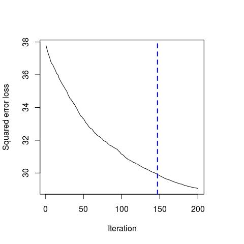

```
## [1] 147
```

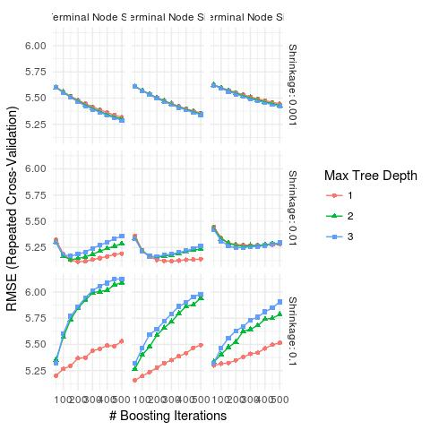

```r
ggplot(gbmFit1, nameInStrip = TRUE)
```

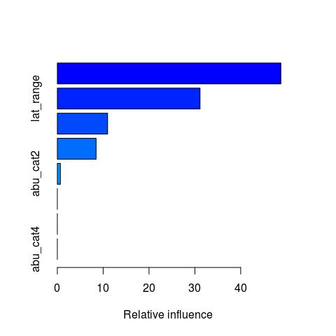

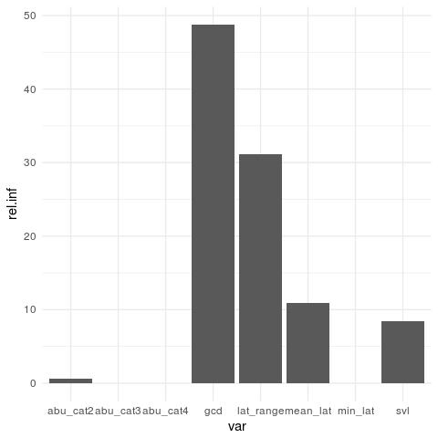

```r
ggplot(as.data.frame(summary(gbmFit1)),
                  aes(x=var, y=rel.inf))+
  geom_col()
```

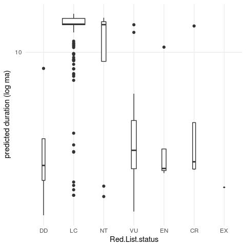

```r
## Prediction
predict.gbm1 <- predict(gbmFit1, newdata = extant, n.trees = gbmFit1$bestTune$n.trees)
res$predict.gbm1 <- predict.gbm1

ggplot(res, aes(x=Red.List.status, y=predict.gbm1))+
  geom_boxplot(varwidth=TRUE)+
  scale_y_log10("predicted duration (log ma)")
```

```r
#### add to other model results
res2 <- melt(res[,c("Red.List.status", "predict.gam", "predict.rf",
                    "predict.gbm1")])
```

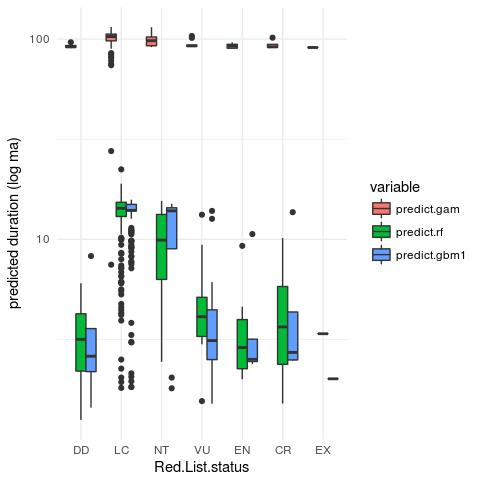

```r
ggplot(res2, aes(x=Red.List.status, y=value))+
  geom_boxplot(aes(fill=variable))+
  scale_y_log10("predicted duration (log ma)")#+
```

```r
#  facet_wrap(~variable)

kruskal.test(res$predict.gbm1, res$Red.List.status)
```

```
##
##  Kruskal-Wallis rank sum test
##
## data:  res$predict.gbm1 and res$Red.List.status
## Kruskal-Wallis chi-squared = 63.483, df = 6, p-value = 8.799e-12
```

```r
pairwise.wilcox.test(res$predict.gbm1, res$Red.List.status, p.adjust.method = "fdr")
```

```
##
##  Pairwise comparisons using Wilcoxon rank sum test
##
## data:  res$predict.gbm1 and res$Red.List.status
##
##    DD    LC      NT    VU    EN    CR
## LC 0.008 -       -     -     -     -
## NT 0.243 0.245   -     -     -     -
## VU 0.560 1.1e-05 0.202 -     -     -
## EN 1.000 7.9e-05 0.243 0.703 -     -
## CR 0.840 0.013   0.471 0.840 0.828 -
## EX 0.840 0.243   0.516 0.560 0.467 0.560
##
## P value adjustment method: fdr
```

Models are quite immune to overfitting and can also deal with correlations of variables. GBM also handles missing data. GBMs make minimal assumptions about the relationship between predictors and response and prioritize predictive performance over probabilistic inference about the model itself.

# More cross validation, and taxonomic-group level mean bias?

The calibration here can basically be done with any other model as well. For now I am using gbm() as I follow the supplementary material of Finnegan et al. 2015 (Science). Assessing the prediction quality is done by using only part of the data to build the model and evaluate it on the remaining data.

### Cross validation bootstrap

```r
size_modelset <- 1/2
fin <- c()
n <- 500
set.seed(346)
interval.range <- 10
interval.size <- 0.5

for(i in 1:n){
  sub <- extinct.imp[sample(seq(1:nrow(extinct.imp)), nrow(extinct.imp)*size_modelset, replace = FALSE),]
  eval <- extinct.imp[-as.numeric(row.names(sub)),]
  gbm.sub <- gbm(ma_range ~ lat_range+gcd+svl+mean_lat+min_lat+abu_cat
                 , data = sub,
                 n.trees=gbmFit1$finalModel$n.trees,
                 shrinkage = gbmFit1$finalModel$shrinkage,
                 interaction.depth=gbmFit1$finalModel$interaction.depth)
  best.iter.sub <- gbm.perf(gbm.sub, method="OOB", plot.it=FALSE)
  pre <- predict.gbm(gbm.sub, eval, best.iter.sub)
    # manually assign every prediction smaller than 0 to be 0 for technical reasons
  pre[pre<0] <- 0

  # group the predicted durations into bins
  g <- findInterval(pre, seq(0, interval.range, interval.size))
  cc <- data.frame(prediction=pre, interval=g, species=eval$species, ma_range=eval$ma_range, order=eval$order)

  # now calculate what was the actual observed duration of the species in these bins
  medians_predicted <- tapply(cc$prediction, cc$interval, median)
  m.df <- data.frame(medians_predicted, interval=as.numeric(names(medians_predicted)))
  medians_observed <- tapply(cc$ma_range, cc$interval, median)
  m.df <- data.frame(m.df, medians_observed)
  temp <- merge(cc, m.df, by="interval", all.x=TRUE)
  temp <- data.frame(temp, run=rep(i, nrow(temp)))
  # add interval name
  temp$interval2 <- seq(0, interval.range, interval.size)[temp$interval]
  # save stuff
  if(i==1){fin <- temp}else{fin <- rbind(fin, temp)}
  # print progress
   if(i %% 10==0) { cat(paste0("iteration: ", i, "\n")) }
} # the bootstrap
```

[output not shown]

[output cut: 495 more lines]

[output not shown]

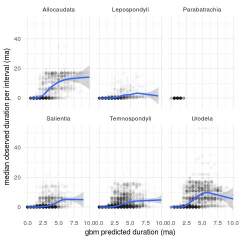

```r
# Add the frequency per interval for weighting the regression:
weights <- data.frame(table(fin$interval2))
fin <- merge(fin, weights, by.x="interval2", by.y="Var1", all.x=TRUE)

# Figure Model calibration 2, supplement of Finnegan et al. 2015 - Paleontological baselines
ggplot(fin[!is.na(fin$order),], aes(x=interval2, y=medians_observed, weight=Freq))+
  geom_point(alpha=1/50)+
#  geom_bin2d()+
  scale_x_continuous("gbm predicted duration (ma)")+
  scale_y_continuous("median observed duration per interval (ma)")+
  geom_smooth()+
  facet_wrap(~order)
```

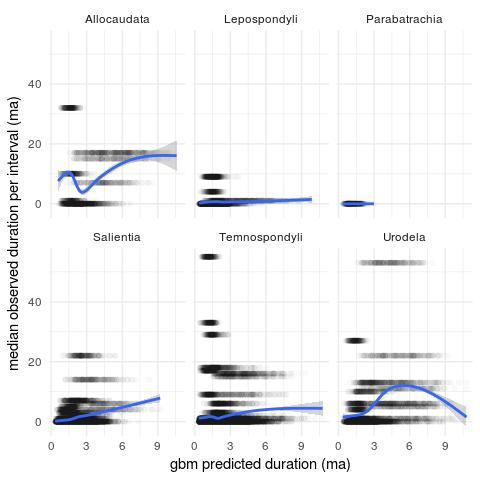

```r
ggplot(fin[!is.na(fin$order),], aes(x=prediction, y=ma_range))+
  geom_point(alpha=1/50)+
#  geom_bin2d()+
  scale_x_continuous("gbm predicted duration (ma)")+
  scale_y_continuous("median observed duration per interval (ma)")+
  geom_smooth()+
  facet_wrap(~order)
```

[figure not shown]

```r
# Get the taxonomic group level bias for each prediction bin. Take the predicted duration value for a living species from the gbm.predict and extract the empirically observed duration from the gam fit
formula = y ~ s(x, bs = "cs")
gam.boot.salientia <- gam(data=fin[fin$order=="Salientia",], medians_observed~s(interval2, bs="cs"), weights=Freq)
gam.boot.urodela <- gam(data=fin[fin$order=="Urodela",], medians_observed~s(interval2, bs="cs"), weights=Freq)

res$predict.gbm1.anura_correction <-  predict(gam.boot.salientia, data.frame(interval2=res$predict.gbm1))
res$predict.gbm1.caudata_correction <-  predict(gam.boot.urodela, data.frame(interval2=res$predict.gbm1))

# plot the effect
par(mfrow=c(1,2))
plot(res$predict.gbm1.anura_correction[res$order=="ANURA"]~res$predict.gbm1[res$order=="ANURA"],
     xlim=c(0,15), ylim=c(0,50), main="Anura", xlab="gbm duration (ma)", ylab="corrected gbm duration (ma)")
abline(a=0, b=1, lty=2)
plot(res$predict.gbm1.caudata_correction[res$order=="CAUDATA"]~res$predict.gbm1[res$order=="CAUDATA"],
     xlim=c(0,15), ylim=c(0,50), main="Caudata", xlab="gbm duration (ma)", ylab="corrected gbm duration (ma)")
abline(a=0, b=1, lty=2)
```

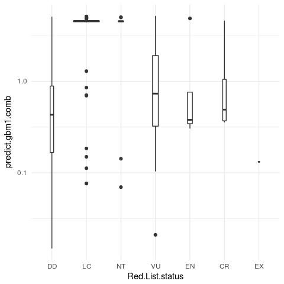

```r
par(mfrow=c(1,1))

# Combine corrected predictions
predict.gbm1.comb <- c()
for(i in 1:nrow(res)){
  if(res$order[i]=="ANURA"){predict.gbm1.comb <- c(predict.gbm1.comb, res$predict.gbm1.anura_correction[i])}else{
    predict.gbm1.comb <- c(predict.gbm1.comb, res$predict.gbm1.caudata_correction[i])
  }
}
res$predict.gbm1.comb <- predict.gbm1.comb
ggplot(res, aes(x=Red.List.status, y=predict.gbm1.comb))+
  geom_boxplot(varwidth=TRUE)+
  scale_y_log10()
```

```r
# add to other model results
res2 <- melt(res[,c("Red.List.status", "predict.gam", "predict.rf",
                    "predict.gbm1", "predict.gbm1.comb")])
```

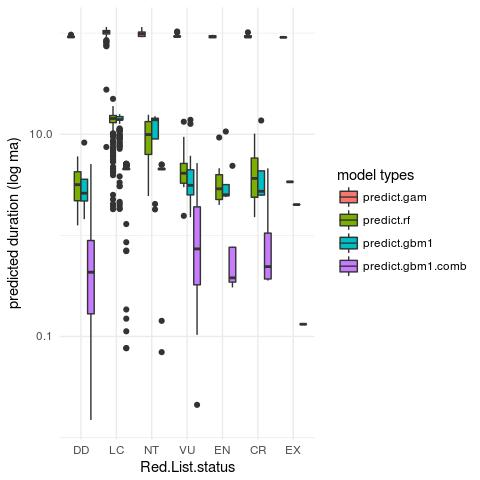

```r
ggplot(res2, aes(x=Red.List.status, y=value))+
  geom_boxplot(aes(fill=variable))+
  scale_fill_discrete(name = "model types")+
  scale_y_log10("predicted duration (log ma)")#+
```

```r
#  facet_wrap(~variable)

kruskal.test(res$predict.gbm1.comb, res$Red.List.status)
```

```
##
##  Kruskal-Wallis rank sum test
##
## data:  res$predict.gbm1.comb and res$Red.List.status
## Kruskal-Wallis chi-squared = 25.781, df = 6, p-value = 0.0002445
```

```r
pairwise.wilcox.test(res$predict.gbm1.comb, res$Red.List.status, p.adjust.method = "fdr")
```

```
##
##  Pairwise comparisons using Wilcoxon rank sum test
##
## data:  res$predict.gbm1.comb and res$Red.List.status
##
##    DD     LC     NT     VU     EN     CR
## LC 0.3892 -      -      -      -      -
## NT 0.7303 0.8842 -      -      -      -
## VU 0.7303 0.0758 0.7303 -      -      -
## EN 1.0000 0.0097 0.5694 0.8278 -      -
## CR 1.0000 0.3892 0.7303 0.8497 0.8842 -
## EX 0.8842 0.3892 0.7303 0.7303 0.6667 0.7303
##
## P value adjustment method: fdr
```

## Phylogenetic bias

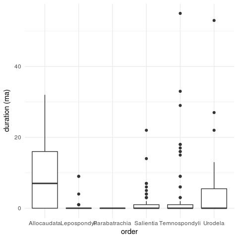

```r
ggplot(extinct.raw[!is.na(extinct.raw$order),], aes(x=order, y=ma_range))+
  geom_boxplot()+
  scale_y_continuous("duration (ma)")
```

```r
pairwise.wilcox.test(extinct.raw$ma_range, extinct.raw$order, p.adjust.method = "fdr")
```

```
##
##  Pairwise comparisons using Wilcoxon rank sum test
##
## data:  extinct.raw$ma_range and extinct.raw$order
##
##               Allocaudata Lepospondyli Parabatrachia Salientia
## Lepospondyli  0.0054      -            -             -
## Parabatrachia 0.2648      0.6300       -             -
## Salientia     0.0121      0.2279       0.4586        -
## Temnospondyli 0.0110      0.2279       0.4586        0.7282
## Urodela       0.1919      0.0263       0.3896        0.1651
##               Temnospondyli
## Lepospondyli  -
## Parabatrachia -
## Salientia     -
## Temnospondyli -
## Urodela       0.0882
##
## P value adjustment method: fdr
```

### Lissamphibian model

```r
liss.raw <- extinct.imp[extinct.imp$order %in% c("Urodela", "Salientia", "Parabatrachia"),]
nrow(liss.raw)
```

```
## [1] 121
```

```r
liss <- liss.raw[,c("ma_range", "lat_range", "gcd", "svl", "mean_lat",
                 "min_lat", "abu_cat")]

set.seed(825)
gbmFit_liss <- train(ma_range ~ ., data = liss, method = "gbm",
                 trControl = gbmControl, verbose=FALSE,
                 tuneGrid=gbmGrid)

gbmFit_liss
```

```
## Stochastic Gradient Boosting
##
## 121 samples
##   6 predictors
##
## No pre-processing
## Resampling: Cross-Validated (10 fold, repeated 3 times)
## Summary of sample sizes: 108, 108, 108, 110, 110, 109, ...
## Resampling results across tuning parameters:
##
##   shrinkage  interaction.depth  n.minobsinnode  n.trees  RMSE
##   0.001      1                   5               50      5.151781
##   0.001      1                   5              100      5.107968
##   0.001      1                   5              150      5.068369
##   0.001      1                   5              200      5.030791
##   0.001      1                   5              250      4.995991
##   0.001      1                   5              300      4.964664
##   0.001      1                   5              350      4.936992
##   0.001      1                   5              400      4.911663
##   0.001      1                   5              450      4.888481
##   0.001      1                   5              500      4.866792
##   0.001      1                  10               50      5.164041
##   0.001      1                  10              100      5.134089
##   0.001      1                  10              150      5.105179
##   0.001      1                  10              200      5.079169
##   0.001      1                  10              250      5.053667
##   0.001      1                  10              300      5.029123
##   0.001      1                  10              350      5.005779
##   0.001      1                  10              400      4.983073
##   0.001      1                  10              450      4.961906
##   0.001      1                  10              500      4.941802
##   0.001      1                  15               50      5.173938
##   0.001      1                  15              100      5.151044
##   0.001      1                  15              150      5.130114
##   0.001      1                  15              200      5.109303
##   0.001      1                  15              250      5.090280
##   0.001      1                  15              300      5.072800
##   0.001      1                  15              350      5.056116
##   0.001      1                  15              400      5.039475
##   0.001      1                  15              450      5.024664
```

[output cut: 501 more lines]

```
##   0.2778902
##   0.2682670
##   0.2667121
##   0.2687449
##   0.2804388
##   0.2854356
##   0.2802373
##   0.2889976
##   0.2896011
##   0.2902973
##   0.2853463
##
## RMSE was used to select the optimal model using  the smallest value.
## The final values used for the model were n.trees = 150,
##  interaction.depth = 3, shrinkage = 0.01 and n.minobsinnode = 5.
```

```r
gbm.perf(gbmFit_liss$finalModel)
```

```
## Using OOB method...
```

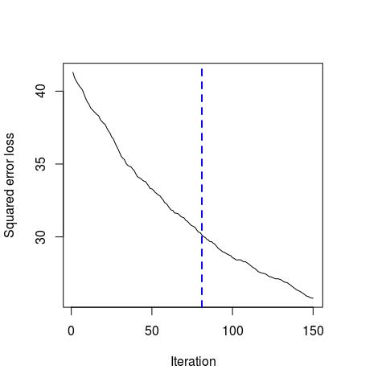

```
## [1] 81
```

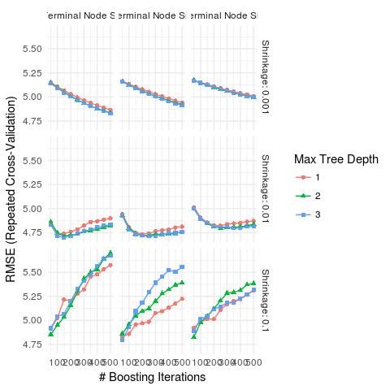

```r
ggplot(gbmFit_liss, nameInStrip = TRUE)
```

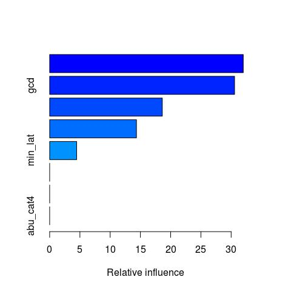

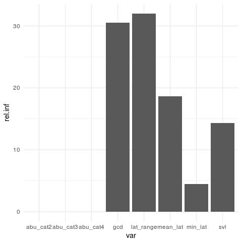

```r
ggplot(as.data.frame(summary(gbmFit_liss)),
                  aes(x=var, y=rel.inf))+
  geom_col()
```

```r
## Prediction
predict.gbm.liss <- predict(gbmFit_liss, newdata = extant, n.trees = gbmFit_liss$bestTune$n.trees)
res$predict.gbm.liss <- predict.gbm.liss

res2 <- melt(res[,c("Red.List.status", "predict.gam", "predict.rf",
                    "predict.gbm1", "predict.gbm1.comb", "predict.gbm.liss")])
```

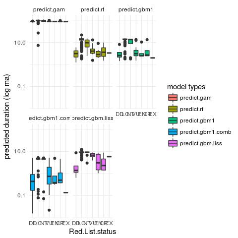

```r
ggplot(res2, aes(x=Red.List.status, y=value))+
  geom_boxplot(aes(fill=variable))+
  scale_fill_discrete(name = "model types")+
  scale_y_log10("predicted duration (log ma)")+
  facet_wrap(~variable)
```

```r
kruskal.test(res$predict.gbm.liss, res$Red.List.status)
```

```
##
##  Kruskal-Wallis rank sum test
##
## data:  res$predict.gbm.liss and res$Red.List.status
## Kruskal-Wallis chi-squared = 63.91, df = 6, p-value = 7.202e-12
```

```r
pairwise.wilcox.test(res$predict.gbm.liss, res$Red.List.status, p.adjust.method = "fdr")
```

```
##
##  Pairwise comparisons using Wilcoxon rank sum test
##
## data:  res$predict.gbm.liss and res$Red.List.status
##
##    DD     LC      NT     VU     EN     CR
## LC 0.0071 -       -      -      -      -
## NT 0.0499 0.8889  -      -      -      -
## VU 0.2039 1.3e-05 0.0424 -      -      -
## EN 0.5147 3.8e-05 0.0255 0.2039 -      -
## CR 0.3231 0.0083  0.0658 0.2039 0.8889 -
## EX 0.8889 0.2039  0.4422 0.7372 0.8889 0.8889
##
## P value adjustment method: fdr
```

```r
set.seed(825)
imp_hab <- merge(extinct.imp, extinct.raw[,c("species", "hab.cat.b")])
imp_hab <- imp_hab[,c("ma_range", "lat_range", "gcd", "svl", "mean_lat", "min_lat", "abu_cat", "hab.cat.b" )]
gbmFit_hab <- train(ma_range ~ ., data = imp_hab, method = "gbm",
                 trControl = gbmControl, verbose=FALSE,
                 tuneGrid=gbmGrid)

gbmFit_hab
```

```
## Stochastic Gradient Boosting
##
## 354 samples
##   7 predictors
##
## No pre-processing
## Resampling: Cross-Validated (10 fold, repeated 3 times)
## Summary of sample sizes: 319, 318, 318, 319, 319, 318, ...
## Resampling results across tuning parameters:
##
##   shrinkage  interaction.depth  n.minobsinnode  n.trees  RMSE
##   0.001      1                   5               50      5.605163
##   0.001      1                   5              100      5.559504
##   0.001      1                   5              150      5.517887
##   0.001      1                   5              200      5.480424
##   0.001      1                   5              250      5.447939
##   0.001      1                   5              300      5.416948
##   0.001      1                   5              350      5.387911
##   0.001      1                   5              400      5.362534
##   0.001      1                   5              450      5.338538
##   0.001      1                   5              500      5.316795
##   0.001      1                  10               50      5.612777
##   0.001      1                  10              100      5.574116
##   0.001      1                  10              150      5.537643
##   0.001      1                  10              200      5.505340
##   0.001      1                  10              250      5.475589
##   0.001      1                  10              300      5.448679
##   0.001      1                  10              350      5.422966
##   0.001      1                  10              400      5.399351
##   0.001      1                  10              450      5.377952
##   0.001      1                  10              500      5.358083
##   0.001      1                  15               50      5.626029
##   0.001      1                  15              100      5.599746
##   0.001      1                  15              150      5.575535
##   0.001      1                  15              200      5.553771
##   0.001      1                  15              250      5.533101
##   0.001      1                  15              300      5.512147
##   0.001      1                  15              350      5.492921
##   0.001      1                  15              400      5.476074
##   0.001      1                  15              450      5.460346
```

[output cut: 501 more lines]

```
##   0.1497112
##   0.2082098
##   0.1976506
##   0.1860141
##   0.1818220
##   0.1756808
##   0.1753356
##   0.1730554
##   0.1676218
##   0.1612181
##   0.1555158
##
## RMSE was used to select the optimal model using  the smallest value.
## The final values used for the model were n.trees = 200,
##  interaction.depth = 1, shrinkage = 0.01 and n.minobsinnode = 5.
```

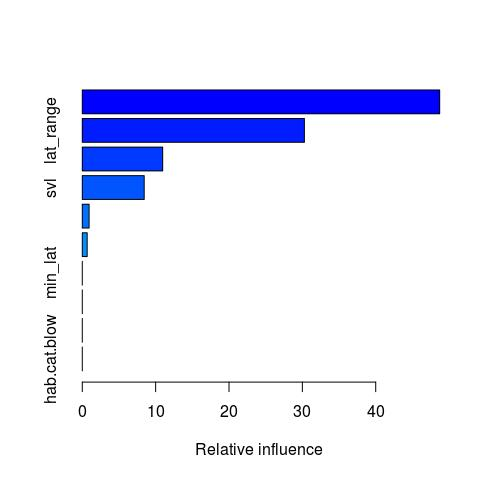

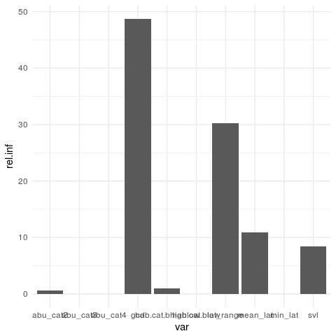

```r
ggplot(as.data.frame(summary(gbmFit_hab)),
                  aes(x=var, y=rel.inf))+
  geom_col()
```

```r
# remember to set resamples="final" in the fitControl
resamps <- resamples(list(GBM = gbmFit1,
                          GBM_LISS = gbmFit_liss,
                          RF = rfFit1,
                          GBM_HAB = gbmFit_hab))
summary(resamps)
ggplot(data.frame)
bwplot(resamps, layout = c(2, 1))
# transform to ggplot

difValues <- diff(resamps)
difValues

summary(difValues)
bwplot(difValues, layout = c(2, 1))

gbmFit1$results[which.min(gbmFit1$results$RMSE),]
gbmFit_liss$results[which.min(gbmFit_liss$results$RMSE),]
gbmFit_hab$results[which.min(gbmFit_hab$results$RMSE),]
rfFit1$results[which.min(rfFit1$results$RMSE),]
```

[output not shown]

## Null model

Our null hypothesis is that we expect no connection between traits and extinction risk. A null model should represent a fit to a random dataset. However, the dataset does not have to be entirely random as this would create species trait combinations that do not make sense (being very rare but extreme widely distributed), just random for the response variable “duration”.

```r
null.data <- imp

set.seed(2)
null.data$ma_range <- sample(null.data$ma_range, replace=FALSE)
  #rnorm(nrow(null.data), mean=mean(extinct$ma_range), sd=sd(extinct$ma_range))
gbm.null <- gbm(data=null.data, log(ma_range+1) ~  lat_range + gcd + svl + mean_lat
                      + min_lat + hab.cat.b + abu_cat, n.trees=n.trees,
                 shrinkage = shrinkage, interaction.depth=interaction.depth)
summary(gbm.null)

## Prediction
predict.gbm.null <- predict(gbm.null, newdata = extant, best.iter)
res$predict.gbm.null <- predict.gbm.null
(gbm.null <- ggplot(res, aes(x=Red.List.status, y=predict.gbm.null))+
  geom_boxplot(varwidth=TRUE)+
  scale_y_log10()+
  theme_classic())


#### add to other model results
res2 <- melt(res[,c("Red.List.status", "fit", "predict.gam1", "predict.gam.poisson",
                    "predict.gam.nb", "predict.rf1", "predict.rf2", "predict.gam1.imp",
                    "predict.gam.comb", "predict.gbm1", "predict.gbm.poisson", "predict.gbm1.comb",
                    "predict.gbm.null")])
ggplot(res2, aes(x=Red.List.status, y=value))+
  geom_boxplot(aes(fill=variable))+
  scale_y_log10()+
  theme_classic()+
  facet_wrap(~variable)

kruskal.test(res$predict.gbm.null, res$Red.List.status)
pairwise.wilcox.test(res$predict.gbm.null, res$Red.List.status, p.adjust.method = "fdr")

# Bootstrap
store_kw <- c()
store_median <- matrix(ncol=8, nrow=500)
for(i in 1:500){
  null.data <- extinct
  null.data$ma_range <- sample(null.data$ma_range, replace=FALSE)
  gbm.null.boot <- gbm(data=null.data, log(ma_range+1) ~  lat_range + gcd + svl + mean_lat
                      + min_lat + hab.cat.b + abu_cat, n.trees=100,
                 shrinkage = shrinkage, interaction.depth=interaction.depth)
  predict.gbm.null.boot <- predict(gbm.null.boot, newdata = extant, n.trees=100)#
  temp <- data.frame(prediction=predict.gbm.null.boot, group=extant$Red.List.status)
  store_median[i,] <- tapply(temp$prediction, temp$group, median)
  store_kw <- c(store_kw, kruskal.test(predict.gbm.null.boot, extant$Red.List.status)$p.value)
  # print progress
   if(i %% 10==0) { cat(paste0("iteration: ", i, "\n")) }
}
hist(store_kw, breaks=80, xlim=c(0,0.1))
boxplot(store_median, names=c("DD", "LC", "NT", "VU", "EN", "CR", "EW", "EX"),
        main="bootstrap null model prediction, n=500",
        ylab="Median duration predicted (log)")
boot.k <- melt(store_median)
kruskal.test(boot.k$value, boot.k$X2)
```

[output not shown]